# Breast cancer microbiome case/control signal implantation benchmark analysis using SIMBA

# 9 Verify our patched SIMBA

Let’s make sure that our modifications do not behave strange using some more sanity checks.

Let us also check that the feature labels and sample labels are preserved.

```r
# ------------------------------------------------------------
# Sanity check: labels and abundances are preserved across
#   1) phyloseq object `ps`
#   2) sim.implant/original_data
#   3) sim.implant implanted group ab1_prev1_rep1
# ------------------------------------------------------------

g <- "ab1_prev1_rep1"

# ---- 1. Extract matrix from phyloseq and ensure taxa are rows ----
ps_mat <- as(otu_table(ps), "matrix")
if (!taxa_are_rows(ps)) {
  ps_mat <- t(ps_mat)
}

# ---- 2. Read original_data from HDF5 ----
orig_feat <- h5read(sim.implant, "original_data/filt_features")
orig_feat_names <- h5read(sim.implant, "original_data/filt_feature_names")
orig_sample_names <- h5read(sim.implant, "original_data/sample_names")

rownames(orig_feat) <- orig_feat_names
colnames(orig_feat) <- orig_sample_names

# ---- 3. Read one implanted group from HDF5 ----
grp <- h5read(sim.implant, g)
sim_feat <- grp$features
rownames(sim_feat) <- grp$feature_names
colnames(sim_feat) <- grp$sample_names

# ---- 4. Check labels before reordering ----
cat("Feature labels before reordering:\n")
cat("  ps vs original_data: ", isTRUE(all.equal(rownames(ps_mat), rownames(orig_feat))), "\n")
cat("  ps vs implanted    : ", isTRUE(all.equal(rownames(ps_mat), rownames(sim_feat))), "\n")
cat("  original vs implant: ", isTRUE(all.equal(rownames(orig_feat), rownames(sim_feat))), "\n\n")

cat("Sample labels before reordering:\n")
cat("  ps vs original_data: ", isTRUE(all.equal(colnames(ps_mat), colnames(orig_feat))), "\n")
cat("  ps vs implanted    : ", isTRUE(all.equal(colnames(ps_mat), colnames(sim_feat))), "\n")
cat("  original vs implant: ", isTRUE(all.equal(colnames(orig_feat), colnames(sim_feat))), "\n\n")

# ---- 5. Reorder all matrices by common feature and sample names ----
common_features <- sort(Reduce(intersect, list(
  rownames(ps_mat), rownames(orig_feat), rownames(sim_feat)
)))
common_samples <- sort(Reduce(intersect, list(
  colnames(ps_mat), colnames(orig_feat), colnames(sim_feat)
)))

ps_sub   <- ps_mat[common_features, common_samples, drop = FALSE]
orig_sub <- orig_feat[common_features, common_samples, drop = FALSE]
sim_sub  <- sim_feat[common_features, common_samples, drop = FALSE]

cat("Dimensions after alignment:\n")
cat("  ps        :", paste(dim(ps_sub), collapse = " x "), "\n")
cat("  original  :", paste(dim(orig_sub), collapse = " x "), "\n")
cat("  implanted :", paste(dim(sim_sub), collapse = " x "), "\n\n")

# ---- 6. Confirm that names now match exactly after reordering ----
cat("Feature labels after reordering:\n")
cat("  ps vs original_data: ", isTRUE(all.equal(rownames(ps_sub), rownames(orig_sub))), "\n")
cat("  ps vs implanted    : ", isTRUE(all.equal(rownames(ps_sub), rownames(sim_sub))), "\n")
cat("  original vs implant: ", isTRUE(all.equal(rownames(orig_sub), rownames(sim_sub))), "\n\n")

cat("Sample labels after reordering:\n")
cat("  ps vs original_data: ", isTRUE(all.equal(colnames(ps_sub), colnames(orig_sub))), "\n")
cat("  ps vs implanted    : ", isTRUE(all.equal(colnames(ps_sub), colnames(sim_sub))), "\n")
cat("  original vs implant: ", isTRUE(all.equal(colnames(orig_sub), colnames(sim_sub))), "\n\n")

# ---- 7. Compare matrix values ----
cat("Matrix equality after alignment:\n")
cat("  ps vs original_data: ", isTRUE(all.equal(ps_sub, orig_sub)), "\n")
cat("  ps vs implanted    : ", isTRUE(all.equal(ps_sub, sim_sub)), "\n")
cat("  original vs implant: ", isTRUE(all.equal(orig_sub, sim_sub)), "\n\n")

cat("Maximum absolute difference:\n")
cat("  ps vs original_data: ", max(abs(ps_sub - orig_sub), na.rm = TRUE), "\n")
cat("  ps vs implanted    : ", max(abs(ps_sub - sim_sub), na.rm = TRUE), "\n")
cat("  original vs implant: ", max(abs(orig_sub - sim_sub), na.rm = TRUE), "\n\n")

# ---- 8. Optional: inspect first mismatch if values differ ----
if (!isTRUE(all.equal(ps_sub, sim_sub))) {
  idx <- which(ps_sub != sim_sub, arr.ind = TRUE)
  if (nrow(idx) > 0) {
    i <- idx[1, "row"]
    j <- idx[1, "col"]
    cat("First ps vs implanted mismatch:\n")
    cat("  feature :", rownames(ps_sub)[i], "\n")
    cat("  sample  :", colnames(ps_sub)[j], "\n")
    cat("  ps      :", ps_sub[i, j], "\n")
    cat("  implant :", sim_sub[i, j], "\n")
  }
}

## Feature labels before reordering:
##   ps vs original_data:  FALSE
##   ps vs implanted    :  FALSE
##   original vs implant:  TRUE
##
## Sample labels before reordering:
##   ps vs original_data:  FALSE
##   ps vs implanted    :  FALSE
##   original vs implant:  TRUE
##
## Dimensions after alignment:
##   ps        : 882 x 261
##   original  : 882 x 261
##   implanted : 882 x 261
##
## Feature labels after reordering:
##   ps vs original_data:  TRUE
##   ps vs implanted    :  TRUE
##   original vs implant:  TRUE
##
## Sample labels after reordering:
##   ps vs original_data:  TRUE
##   ps vs implanted    :  TRUE
##   original vs implant:  TRUE
##
## Matrix equality after alignment:
##   ps vs original_data:  TRUE
##   ps vs implanted    :  TRUE
##   original vs implant:  TRUE
##
## Maximum absolute difference:
##   ps vs original_data:  0
##   ps vs implanted    :  0
##   original vs implant:  0
```

Verify that the implanted markers are the only ones that changed.

```r
g <- "ab15_prev1_rep1"

# ------------------------------------------------------------
# 1. Read original and implanted feature tables
# ------------------------------------------------------------

# original data
orig_feat <- h5read(sim.implant, "original_data/filt_features")
orig_feat_names <- h5read(sim.implant, "original_data/filt_feature_names")
orig_sample_names <- h5read(sim.implant, "original_data/sample_names")

rownames(orig_feat) <- orig_feat_names
colnames(orig_feat) <- orig_sample_names

# implanted group
grp <- h5read(sim.implant, g)
sim_feat <- grp$features
rownames(sim_feat) <- grp$feature_names
colnames(sim_feat) <- grp$sample_names

marker_idx <- grp$marker_idx
label <- grp$labels
names(label) <- grp$sample_names

# ------------------------------------------------------------
# 2. Align by feature and sample names
# ------------------------------------------------------------

common_features <- sort(intersect(rownames(orig_feat), rownames(sim_feat)))
common_samples  <- sort(intersect(colnames(orig_feat), colnames(sim_feat)))

orig_sub <- orig_feat[common_features, common_samples, drop = FALSE]
sim_sub  <- sim_feat[common_features, common_samples, drop = FALSE]

label_sub <- label[common_samples]

cat("Aligned dimensions:\n")
cat("  original :", paste(dim(orig_sub), collapse = " x "), "\n")
cat("  implanted:", paste(dim(sim_sub), collapse = " x "), "\n\n")

# ------------------------------------------------------------
# 3. Which features actually changed?
# ------------------------------------------------------------

# any count change at all in at least one sample
changed_feature <- rowSums(orig_sub != sim_sub, na.rm = TRUE) > 0
changed_features <- rownames(orig_sub)[changed_feature]

cat("Features listed in marker_idx      :", length(marker_idx), "\n")
cat("Features with any observed change  :", length(changed_features), "\n")
cat("Intersection(marker_idx, changed)  :", length(intersect(marker_idx, changed_features)), "\n")
cat("Markers with no observed change    :", length(setdiff(marker_idx, changed_features)), "\n")
cat("Changed but not in marker_idx      :", length(setdiff(changed_features, marker_idx)), "\n\n")

# show examples if something looks wrong
cat("First marker_idx entries:\n")
print(head(sort(marker_idx), 10))

cat("\nFirst changed features:\n")
print(head(sort(changed_features), 10))

cat("\nMarkers with no observed change:\n")
print(head(setdiff(marker_idx, changed_features), 10))

cat("\nChanged but not in marker_idx:\n")
print(head(setdiff(changed_features, marker_idx), 10))

# ------------------------------------------------------------
# 4. Summarize per-feature change magnitude
# ------------------------------------------------------------

qc_df <- tibble(
  feature = rownames(orig_sub),
  is_marker = rownames(orig_sub) %in% marker_idx,
  n_changed_samples = rowSums(orig_sub != sim_sub, na.rm = TRUE),
  mean_abs_diff = rowMeans(abs(sim_sub - orig_sub), na.rm = TRUE),
  sum_abs_diff = rowSums(abs(sim_sub - orig_sub), na.rm = TRUE),
  prevalence_orig = rowMeans(orig_sub > 0, na.rm = TRUE),
  prevalence_sim  = rowMeans(sim_sub > 0, na.rm = TRUE)
) %>%
  arrange(desc(sum_abs_diff), desc(n_changed_samples))

cat("\nTop features by total absolute change:\n")
print(qc_df %>% select(feature, is_marker, n_changed_samples, sum_abs_diff, mean_abs_diff) %>% head(20))

# ------------------------------------------------------------
# 5. Check expected class separation among markers
# ------------------------------------------------------------

# compare mean relative abundance by class before and after implantation
orig_rel <- sweep(orig_sub, 2, colSums(orig_sub), FUN = "/")
sim_rel  <- sweep(sim_sub, 2, colSums(sim_sub), FUN = "/")

pos_samples <- names(label_sub)[label_sub == 1]
neg_samples <- names(label_sub)[label_sub == -1]

marker_effect_df <- tibble(
  feature = marker_idx[marker_idx %in% rownames(sim_rel)],
  orig_mean_pos = rowMeans(orig_rel[marker_idx[marker_idx %in% rownames(sim_rel)], pos_samples, drop = FALSE], na.rm = TRUE),
  orig_mean_neg = rowMeans(orig_rel[marker_idx[marker_idx %in% rownames(sim_rel)], neg_samples, drop = FALSE], na.rm = TRUE),
  sim_mean_pos  = rowMeans(sim_rel [marker_idx[marker_idx %in% rownames(sim_rel)], pos_samples, drop = FALSE], na.rm = TRUE),
  sim_mean_neg  = rowMeans(sim_rel [marker_idx[marker_idx %in% rownames(sim_rel)], neg_samples, drop = FALSE], na.rm = TRUE)
) %>%
  mutate(
    orig_diff = orig_mean_pos - orig_mean_neg,
    # true implanted separation after simulation
    sim_diff  = sim_mean_pos - sim_mean_neg,
    abs_sim_diff = abs(sim_diff)
  ) %>%
  arrange(desc(abs_sim_diff))

cat("\nTop implanted markers by absolute class separation after implantation:\n")
print(marker_effect_df %>% select(feature, sim_mean_pos, sim_mean_neg, sim_diff, abs_sim_diff) %>% head(20))

# ------------------------------------------------------------
# 6. Quick pass/fail summary
# ------------------------------------------------------------

all_markers_changed <- setequal(intersect(marker_idx, rownames(orig_sub)), intersect(marker_idx, changed_features))
no_nonmarkers_changed <- length(setdiff(changed_features, marker_idx)) == 0

cat("\nQC flags:\n")
cat("  all markers changed at least somewhere : ", all_markers_changed, "\n")
cat("  no non-marker changed                  : ", no_nonmarkers_changed, "\n")
## Aligned dimensions:
##   original : 882 x 261
##   implanted: 882 x 261
##
## Features listed in marker_idx      : 88
## Features with any observed change  : 88
## Intersection(marker_idx, changed)  : 88
## Markers with no observed change    : 0
## Changed but not in marker_idx      : 0
##
## First marker_idx entries:
##  [1] "ext_mOTU_v3_16202" "ext_mOTU_v3_16208" "ext_mOTU_v3_16226"
##  [4] "ext_mOTU_v3_16259" "ext_mOTU_v3_16285" "ext_mOTU_v3_16451"
##  [7] "ext_mOTU_v3_17344" "ext_mOTU_v3_17404" "ext_mOTU_v3_17436"
## [10] "ext_mOTU_v3_17441"
##
## First changed features:
##  [1] "ext_mOTU_v3_16202" "ext_mOTU_v3_16208" "ext_mOTU_v3_16226"
##  [4] "ext_mOTU_v3_16259" "ext_mOTU_v3_16285" "ext_mOTU_v3_16451"
##  [7] "ext_mOTU_v3_17344" "ext_mOTU_v3_17404" "ext_mOTU_v3_17436"
## [10] "ext_mOTU_v3_17441"
##
## Markers with no observed change:
## character(0)
##
## Changed but not in marker_idx:
## character(0)
##
## Top features by total absolute change:
## # A tibble: 20 × 5
##    feature            is_marker n_changed_samples sum_abs_diff mean_abs_diff
##    <chr>              <lgl>                 <dbl>        <dbl>         <dbl>
##  1 ref_mOTU_v3_03691  TRUE                    119       553737        2122.
##  2 ref_mOTU_v3_03069  TRUE                    230       328383        1258.
##  3 ref_mOTU_v3_03701  TRUE                     82       238328         913.
##  4 meta_mOTU_v3_12301 TRUE                    228       108052         414.
##  5 ref_mOTU_v3_00861  TRUE                    247       105555         404.
##  6 ref_mOTU_v3_03686  TRUE                     40        91867         352.
##  7 meta_mOTU_v3_12327 TRUE                    149        56274         216.
##  8 ref_mOTU_v3_05139  TRUE                    247        53758         206.
##  9 ref_mOTU_v3_01014  TRUE                    212        47160         181.
## 10 meta_mOTU_v3_12452 TRUE                    184        36271         139.
## 11 ext_mOTU_v3_18130  TRUE                    164        35485         136.
## 12 ref_mOTU_v3_07691  TRUE                     44        29432         113.
## 13 meta_mOTU_v3_12537 TRUE                    120        28293         108.
## 14 meta_mOTU_v3_12314 TRUE                    159        25250          96.7
## 15 meta_mOTU_v3_12664 TRUE                     77        23044          88.3
## 16 meta_mOTU_v3_12270 TRUE                     97        22819          87.4
## 17 ref_mOTU_v3_02700  TRUE                     67        22709          87.0
## 18 meta_mOTU_v3_12691 TRUE                    102        19266          73.8
## 19 meta_mOTU_v3_12744 TRUE                    123        17082          65.4
## 20 meta_mOTU_v3_12633 TRUE                     29        16778          64.3
##
## Top implanted markers by absolute class separation after implantation:
## # A tibble: 20 × 5
##    feature            sim_mean_pos sim_mean_neg sim_diff abs_sim_diff
##    <chr[1d]>                 <dbl>        <dbl>    <dbl>        <dbl>
##  1 ref_mOTU_v3_03691     0.00336      0.0943    -0.0909       0.0909
##  2 ref_mOTU_v3_03069     0.00163      0.0686    -0.0670       0.0670
##  3 ref_mOTU_v3_03701     0.00242      0.0404    -0.0380       0.0380
##  4 meta_mOTU_v3_12301    0.000404     0.0260    -0.0256       0.0256
##  5 ref_mOTU_v3_00861     0.000492     0.0240    -0.0235       0.0235
##  6 ref_mOTU_v3_01014     0.0216       0.000331   0.0212       0.0212
##  7 ref_mOTU_v3_03686     0.000196     0.0178    -0.0176       0.0176
##  8 meta_mOTU_v3_12452    0.0151       0.000254   0.0149       0.0149
##  9 ref_mOTU_v3_05139     0.000342     0.0139    -0.0136       0.0136
## 10 meta_mOTU_v3_12327    0.000351     0.0136    -0.0132       0.0132
## 11 ref_mOTU_v3_07691     0.0131       0.000183   0.0129       0.0129
## 12 meta_mOTU_v3_12537    0.0122       0.000194   0.0120       0.0120
## 13 meta_mOTU_v3_12270    0.0120       0.0000942  0.0119       0.0119
## 14 ext_mOTU_v3_18130     0.000142     0.0103    -0.0102       0.0102
## 15 ref_mOTU_v3_11851     0.00801      0.0000985  0.00791      0.00791
## 16 meta_mOTU_v3_12744    0.00776      0.000114   0.00765      0.00765
## 17 ref_mOTU_v3_03634     0.00752      0.000101   0.00742      0.00742
## 18 meta_mOTU_v3_12691    0.00666      0.000232   0.00643      0.00643
## 19 ref_mOTU_v3_02700     0.0000236    0.00604   -0.00602      0.00602
## 20 meta_mOTU_v3_12314    0.000160     0.00609   -0.00593      0.00593
##
## QC flags:
##   all markers changed at least somewhere :  TRUE
##   no non-marker changed                  :  TRUE
```

Verify that running the `apply.test()` function from SIMBA still works as expected. Nothing should be detected because we are testing `ab.scale=1` here.

```r
alpha <- 0.05
rep_col <- "rep_1"

g <- "ab1_prev1_rep1"
subset_name <- "subset_261"

grp <- rhdf5::h5read(sim.implant, g)
marker_idx_h5 <- grp$marker_idx

res <- apply.test(
  sim.location = sim.implant,
  group = g,
  subset = 261,
  norm = "pass",
  test = "LinDA",
  covariates = c("Age")
)
## + Checking testing parameters!
## ++ Received covariate pass-through for [Age]. Ignoring confounders.
## ++ Finished calculations for subset_261
## + Finished calculations for group ab1_prev1_rep1

pval_mat <- res[["p.val"]][[g]][[subset_name]]
head(rownames(pval_mat))
eff_mat <- res[["eff.size"]][[g]][[subset_name]]
eff <- eff_mat[, rep_col]

sum(marker_idx_h5 %in% rownames(pval_mat))
setdiff(marker_idx_h5, rownames(pval_mat))

p <- pval_mat[, rep_col]
padj <- p.adjust(p, method = "fdr")
res_df <- data.frame(feature=names(eff), pval=p, padj=padj, effect_size=eff)

detected <- names(padj)[padj < alpha]

cat("Detected taxa:", length(detected), "\n")
cat("True markers:", length(marker_idx_h5), "\n")
cat("True positives:", sum(detected %in% marker_idx_h5), "\n")
cat("False positives:", sum(!detected %in% marker_idx_h5), "\n")
cat("Manual power:", mean(marker_idx_h5 %in% detected), "\n")

## [1] "ext_mOTU_v3_15391" "ext_mOTU_v3_15440" "ext_mOTU_v3_15441"
## [4] "ext_mOTU_v3_15442" "ext_mOTU_v3_15443" "ext_mOTU_v3_15444"
## [1] 88
## character(0)
## Detected taxa: 0
## True markers: 88
## True positives: 0
## False positives: 0
## Manual power: 0
```

# 10 Prepare the benchmark groups

SIMBA stores one HDF5 group per simulation setting. The chunks below identify all groups and restrict the analysis to the intended number of simulation repeats.

```r
temp <- rhdf5::h5ls(sim.implant, recursive = FALSE)
groups <- setdiff(temp$name, c("original_data", "simulation_parameters"))

# Keep abundance-scale groups with the single prevalence setting used here.
groups.sub <- groups[grepl("^ab[0-9]+_prev1_rep[0-9]+$", groups)]

# Restrict to the requested number of simulation repeats.
groups.sub <- groups.sub[
  as.integer(stringr::str_match(groups.sub, "^ab[0-9]+_prev1_rep([0-9]+)$")[, 2]) <= REPS_USED
]

rm(temp, groups)
```

# 11 Benchmark multiple differential abundance methods

The benchmark runs one method at a time across all simulated groups and then aggregates performance metrics across repeats.

## 11.1 Run the benchmark

The normalization strategy is chosen separately for each method. Calibration tables are also extracted where available, as they are needed later for detectability-boundary analyses.

```r
test_names <- c(
  "LinDA",
  "metagenomeSeq",
  "ANCOMBC2", "ANCOMBC",
  "DESeq2", "lm", "edgeR"
)

force_DA_tests <- FALSE
filename = file.path(simh5.loc, paste0("BC_", param_set, "_eval_summary.rds"))
if (!file.exists(filename) || force_DA_tests) {

  # Modify this
  n_workers <- n_cpus

  if (n_workers > 1) {
    future::plan(future::multisession, workers = n_workers)
  } else {
    future::plan("sequential")
  }

  method_results_BC <- test_names %>%
    set_names() %>%
    purrr::map(function(test_name) {
      # Method-specific normalization
      norm_method <- dplyr::case_when(
        test_name == "lm" ~ "clr_halfmin",
        test_name == "wilcoxon" ~ "TSS",
        test_name == "LinDA" ~ "TSS",
        TRUE ~ "pass"
      )

      # Covariate adjustment where relevant
      covariates <- NULL
      if (test_name %in% c("LinDA", "metagenomeSeq", "lm", "ANCOMBC", "ANCOMBC2", "DESeq2", "edgeR")) {
        covariates <- c("Age")
      }

      # Some methods do not currently return effect sizes in the patched workflow
      return_calib <- TRUE

      simbaR::run_method_eval_parallel(
        test_name = test_name,
        groups.sub = groups.sub,
        sim.implant = sim.implant,
        subset_size = subset_size,
        ab.scale = ab.scale,
        alpha = ALPHA,
        norm = norm_method,
        covariates = covariates,
        seed = TRUE,
        show_progress = TRUE,
        simba.loc = NULL,
        return_calib = return_calib
      )
    })
  saveRDS(method_results_BC, file = filename)
} else {
  method_results_BC <- readRDS(file = filename)
}
```

## 11.2 Summarize benchmark performance

```r
master_evals_BC <- dplyr::bind_rows(purrr::map(method_results_BC, "evals"))

power_combined_benchmark_BC <- master_evals_BC %>%
  group_by(test, ab_scale, prev_index) %>%
  summarise(
    mean_power = mean(power, na.rm = TRUE),
    sd_power = sd(power, na.rm = TRUE),
    mean_fdr = mean(empirical_fdr, na.rm = TRUE),
    sd_fdr = sd(empirical_fdr, na.rm = TRUE),
    mean_precision = mean(precision, na.rm = TRUE),
    mean_auroc = mean(auroc, na.rm = TRUE),
    mean_abs_eff_tp2 = mean(mean_abs_eff_tp, na.rm = TRUE),
    sd_abs_eff_tp = sd(mean_abs_eff_tp, na.rm = TRUE),
    mean_abs_eff_marker2 = mean(mean_abs_eff_marker, na.rm = TRUE),
    sd_abs_eff_marker = sd(mean_abs_eff_marker, na.rm = TRUE),
    n_reps = n(),
    .groups = "drop"
  )

datatable(power_combined_benchmark_BC)
```

|  | test | ab_scale | prev_index | mean_power | sd_power | mean_fdr | sd_fdr | mean_precision | mean_auroc | mean_abs_eff_tp2 | sd_abs_eff_tp | mean_abs_eff_marker2 | sd_abs_eff_marker | n_reps |
| --- | --- | --- | --- | --- | --- | --- | --- | --- | --- | --- | --- | --- | --- | --- |
| 1 | ANCOMBC | 1 | 1 | 0 | 0 | 0 | 0 | 0 | 0.5026887156842738 |  |  | 0.1215608684967512 | 0.01207143765758569 | 50 |
| 2 | ANCOMBC | 1.5 | 1 | 0.1598834171709071 | 0.05261026427980876 | 0.1611791241785045 | 0.06175002442516389 | 0.8388208758214954 | 0.7383658861849923 | 0.6007538062874583 | 0.06932106478987049 | 0.2640310500199263 | 0.0229028871195866 | 50 |
| 3 | ANCOMBC | 2 | 1 | 0.4888531870428422 | 0.05220180602683427 | 0.1696511665654279 | 0.02390619720756401 | 0.8303488334345721 | 0.8364299630996099 | 0.6862925697532813 | 0.04175072621785234 | 0.4408709068662647 | 0.03117464903632398 | 50 |
| 4 | ANCOMBC | 2.5 | 1 | 0.592110762800418 | 0.05895886927339464 | 0.1774405989589144 | 0.02235001465758927 | 0.8225594010410856 | 0.876229879751945 | 0.7738338432153989 | 0.05553684913939712 | 0.5462214066144317 | 0.04430291370579158 | 50 |
| 5 | ANCOMBC | 3 | 1 | 0.6942398119122257 | 0.04877576717218586 | 0.1829471284069503 | 0.01372533617549461 | 0.8170528715930497 | 0.9002862349810775 | 0.856144978779658 | 0.05814691555608471 | 0.6583874209967567 | 0.05049531744737295 | 50 |
| 6 | ANCOMBC | 3.5 | 1 | 0.7482549634273772 | 0.0492924327572733 | 0.1818094948793206 | 0.01952093791966219 | 0.8181905051206794 | 0.9188839126343054 | 0.9178496065129044 | 0.06189393291042974 | 0.7418316337060229 | 0.06294542810493373 | 50 |
| 7 | ANCOMBC | 4 | 1 | 0.767539184952978 | 0.04884089504601942 | 0.1800488833337488 | 0.01448437939556451 | 0.8199511166662512 | 0.8762600688210348 | 1.008123749127942 | 0.0693540958341938 | 0.8119766757208974 | 0.0648458120265127 | 50 |
| 8 | ANCOMBC | 4.5 | 1 | 0.7852716823406478 | 0.04094204990055685 | 0.1759403845991547 | 0.01364876549345057 | 0.8240596154008454 | 0.8810291177231873 | 1.066172155378526 | 0.07923764641484048 | 0.8719003967477891 | 0.0701648853770903 | 50 |
| 9 | ANCOMBC | 5 | 1 | 0.801721525600836 | 0.03887342927436124 | 0.1800542283157209 | 0.01481470894622484 | 0.8199457716842791 | 0.8802301676057117 | 1.131631812378004 | 0.08066441462301144 | 0.9361110194080564 | 0.0775184014368452 | 50 |
| 10 | ANCOMBC | 5.5 | 1 | 0.81587513061651 | 0.03575357783677756 | 0.1775166782472566 | 0.0139697883093955 | 0.8224833217527434 | 0.887930140050497 | 1.176157980212781 | 0.08713877567036579 | 0.9869650283421365 | 0.07793708657714439 | 50 |

[output cut: 123 more lines]

## 11.3 Visualize benchmark performance

These plots provide the benchmark overview used to select methods for the downstream detectability analyses.

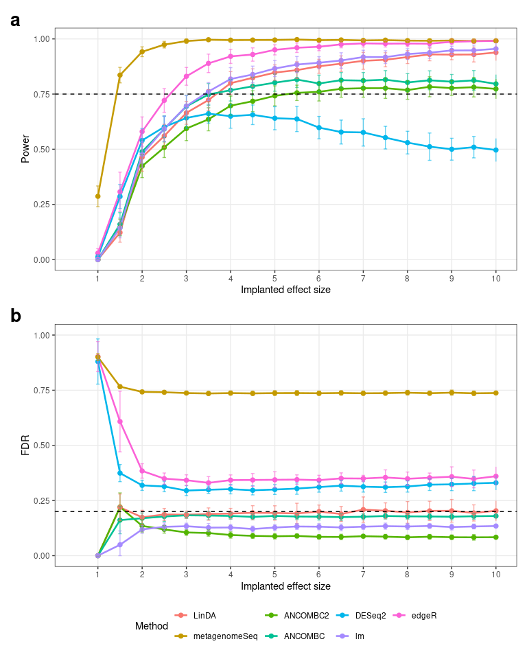

```r
plot_df <- power_combined_benchmark_BC %>%
  filter(test %in% test_names) %>%
  mutate(test = factor(test, levels = test_names))

p_fdr <- ggplot(plot_df, aes(x = ab_scale, y = mean_fdr, color = test, group = test)) +
  geom_line(linewidth = 0.9) +
  geom_point(size = 2) +
  geom_errorbar(
    aes(
      ymin = pmax(0, mean_fdr - sd_fdr),
      ymax = pmin(1, mean_fdr + sd_fdr)
    ),
    width = 0.08,
    alpha = 0.6
  ) +
  #geom_hline(yintercept = ALPHA, linetype = 2) +
  geom_hline(yintercept = 0.20, linetype = 2) +
  scale_x_continuous(limits = c(0.5, 10), breaks = seq(1, 10)) +
  scale_y_continuous(limits = c(0, 1)) +
  labs(
    x = "Implanted effect size",
    y = "FDR",
    color = "Method"
  ) +
  theme_bw() +
  theme(panel.grid.minor = element_blank())

p_power <- ggplot(plot_df, aes(x = ab_scale, y = mean_power, color = test, group = test)) +
  geom_line(linewidth = 0.9) +
  geom_point(size = 2) +
  geom_errorbar(
    aes(
      ymin = pmax(0, mean_power - sd_power),
      ymax = pmin(1, mean_power + sd_power)
    ),
    width = 0.08,
    alpha = 0.6
  ) +
  geom_hline(yintercept = 0.75, linetype = 2) +
  #geom_hline(yintercept = 0.4, linetype = 2) +
  scale_x_continuous(limits = c(0.5, 10), breaks = seq(1, 10)) +
  scale_y_continuous(limits = c(0, 1)) +
  labs(
    x = "Implanted effect size",
    y = "Power",
    color = "Method"
  ) +
  theme_bw() +
  theme(panel.grid.minor = element_blank())

BC_summary_plot <- ((p_power + labs(tag = "a")) / (p_fdr + labs(tag = "b"))) +
  plot_layout(guides = "collect") &
  theme(
    legend.position = "bottom",
    plot.tag = element_text(size = 20, face = "bold")
  )

BC_summary_plot
```

```r
ggsave(filename = file.path(out.loc, paste0("BC_", param_set, "_summary.pdf")),
       plot = BC_summary_plot,
       device = cairo_pdf,
       width = 8,
       height = 10)
ggsave(filename = file.path(out.loc, paste0("BC_", param_set, "_power.pdf")), plot = p_power, width = 8, height = 5)
ggsave(filename = file.path(out.loc, paste0("BC_", param_set, "_fdr.pdf")), plot = p_fdr, width = 8, height = 5)
```

# 12 Build the calibration table

The calibration analysis uses method-specific p-values and effect sizes extracted from the benchmarked simulations.

```r
master_calib_BC <- dplyr::bind_rows(purrr::map(method_results_BC, "calib_df")) %>%
  mutate(
    detected = as.logical(padj < ALPHA),
    is_tp = as.logical(detected & is_marker),
    is_fp = as.logical(detected & !is_marker)
  )
```

# 13 Select methods for interpretability analysis

```r
good_ones <- power_combined_benchmark_BC %>%
  filter(mean_power >= 0.75 & mean_fdr <= 0.20) %>%
  group_by(test) %>%
  filter(rank(ab_scale, ties.method = "first") == 1) %>%
  arrange(ab_scale, test)
datatable(good_ones)
```

|  | test | ab_scale | prev_index | mean_power | sd_power | mean_fdr | sd_fdr | mean_precision | mean_auroc | mean_abs_eff_tp2 | sd_abs_eff_tp | mean_abs_eff_marker2 | sd_abs_eff_marker | n_reps |
| --- | --- | --- | --- | --- | --- | --- | --- | --- | --- | --- | --- | --- | --- | --- |
| 1 | lm | 3.5 | 1 | 0.7616509926854754 | 0.04038087694769255 | 0.1271180928131865 | 0.01825270799544352 | 0.8728819071868135 | 0.9635293718732055 | 0.5278421010924135 | 0.03492808292810042 | 0.4400360153849081 | 0.03396048605020452 | 50 |
| 2 | ANCOMBC | 4 | 1 | 0.767539184952978 | 0.04884089504601942 | 0.1800488833337488 | 0.01448437939556451 | 0.8199511166662512 | 0.8762600688210348 | 1.008123749127942 | 0.0693540958341938 | 0.8119766757208974 | 0.0648458120265127 | 50 |
| 3 | LinDA | 4 | 1 | 0.7993913270637408 | 0.05232323173084748 | 0.1908934906332622 | 0.02338722757066266 | 0.8091065093667378 | 0.963070041473406 | 1.708623253632028 | 0.105026161569491 | 1.460813274327969 | 0.1030249468086299 | 50 |
| 4 | ANCOMBC2 | 5.5 | 1 | 0.7556295715778475 | 0.0348879512846497 | 0.0893875169697472 | 0.00889068035808047 | 0.9106124830302528 | 0.8490441698362841 | 2.810112188942293 | 0.05761640238268444 | 2.515812350175503 | 0.09406358006413953 | 50 |

```r
methods_keep <- sort(good_ones$test)
methods_keep
```

```
## [1] "ANCOMBC"  "ANCOMBC2" "LinDA"    "lm"
```

# 14 Run the real-data differential abundance analyses

The next step is to run the corresponding differential abundance methods on the real breast cancer case/control data. These results are then compared with the simulation-derived detectability boundaries.

```r
# prepare the tables
ps2 <- filter_taxa_by_prevalence(ps, MIN_DISCOVERY_PREVALENCE)
ps2rel <- transform_sample_counts(ps2, function(x) x / sum(x))
real_feat_relab <- as(otu_table(ps2rel), "matrix")
real_feat_relab <- as.data.frame(real_feat_relab[, rownames(meta)])

# Run DA test on real data

force_DA_tests <- FALSE

param_set2 <- paste("alpha", ALPHA, "prev", MIN_DISCOVERY_PREVALENCE, "reps", REPS_USED, sep = "_")
filename = file.path(simh5.loc, paste0("BC_", param_set2, "_real_data.rds"))

if (!file.exists(filename) || force_DA_tests) {

  # DESeq2

  sample_data(ps2)[["DiseaseStatus.binary"]] <- factor(sample_data(ps2)[["DiseaseStatus.binary"]],
                                                       levels=c(1,2),
                                                       ordered=FALSE)
  DES = phyloseq_to_deseq2(ps2, as.formula("~ Age + DiseaseStatus.binary"))
  dds <- estimateSizeFactors(DES, type = "poscounts")
  dds <- DESeq(dds,
               fitType = "parametric",
               test = "Wald",
               quiet = TRUE,
               minReplicatesForReplace = Inf
  )
  res_DESeq2 <- as.data.frame(results(dds, contrast = c("DiseaseStatus.binary", c(1, 2)), cooksCutoff = TRUE))

  # Encode as 1/2 as 0/1

  meta$DiseaseStatus.binary <- meta$DiseaseStatus.binary - 1
  sample_data(ps2) <- meta

  # ANCOMBC2
  res_ancombc2 <- ancombc2(
    data = ps2,
    fix_formula = "DiseaseStatus.binary + Age",
    rand_formula = NULL,
    p_adj_method = "fdr",
    prv_cut = MIN_DISCOVERY_PREVALENCE,
    lib_cut = 1000,
    alpha = ALPHA
  )
  # Filter for sensitivity analysis
  res_ancombc2$res <- res_ancombc2$res %>%
    dplyr::mutate(p_DiseaseStatus.binary = replace(p_DiseaseStatus.binary, passed_ss_DiseaseStatus.binary != TRUE, 1))

  # ANCOMBC
  res_ancombc <- ancombc(
    data = ps2,
    formula = "DiseaseStatus.binary + Age",
    p_adj_method = "fdr",
    pseudo = 1,
    prv_cut = MIN_DISCOVERY_PREVALENCE,
    lib_cut = 1000
  )

  # Re-encode 0/1 as -1/+1
  newlabel <- as.numeric(meta$DiseaseStatus.binary)
  newlabel[newlabel == 0] <- -1
  # newlabel[newlabel == 1] <- 1
  meta$DiseaseStatus.binary <- newlabel

  # lm on clr-transformed abundance with a half-minimum pseudocount
  tab_analysis <- as(otu_table(ps2), "matrix")
  pseudo <- min(tab_analysis[tab_analysis > 0]) / 2
  tab_analysis[tab_analysis == 0] <- pseudo
  tab_analysis <- as.data.frame(apply(tab_analysis, 1, compositions::clr))

  fit_one <- function(y, meta) {
    d <- cbind(meta, y = as.numeric(y))
    fit <- lm(y ~ DiseaseStatus.binary + Age, data = d)
    res <- broom.mixed::tidy(fit, effects = "fixed")
    res[res$term == "DiseaseStatus.binary", ]
  }

  res_lm <- apply(tab_analysis, MARGIN=2, FUN = fit_one, meta = meta) %>%
    bind_rows(.id = "OTU") %>%
    mutate(padj = p.adjust(p.value, method = "fdr"))

  # LinDA on relative abundance

  meta$DiseaseStatus.binary = factor(meta$DiseaseStatus.binary, levels=c(-1, 1))
  res_linda <- LinDA::linda(
    real_feat_relab,
    meta,
    formula = "~ DiseaseStatus.binary + Age",
    alpha = ALPHA,
    p.adj.method = "BH",
    type = "proportion"
  )

  # metagenomeSeq

  sample_data(ps2) <- meta # take the version with factors and -1/+1

  m <- phyloseq_to_metagenomeSeq(ps2)
  m2 <- filterData(m, present = nsamples(ps2) * MIN_DISCOVERY_PREVALENCE, depth = 1000)
  p <- cumNormStat(m2)
  m2 <- cumNorm(m2, p = p)
  pd <- pData(m2)

  mod1 <- model.matrix(~ DiseaseStatus.binary + Age, data = pd)
  res1 <- fitZig(m2, mod1, control = zigControl(maxit = 20, verbose = FALSE))
  res_metagenomeSeq <- MRcoefs(res1, number = nrow(res1), adjustMethod = "fdr")


  # Store raw p-values and effect sizes for downstream interpretability analyses
  p_lm_real <- as.numeric(res_lm$p.value)
  eff_lm_real <- as.numeric(res_lm$estimate)
  p_linda_real = res_linda$output$DiseaseStatus.binary$pvalue
  eff_linda_real = res_linda$output$DiseaseStatus.binary$log2FoldChange
  p_mgs_real <- res_metagenomeSeq$pvalues
  eff_mgs_real <- res_metagenomeSeq$DiseaseStatus.binary1
  p_ancombc_real <- res_ancombc$res$p_val$DiseaseStatus.binary
  eff_ancombc_real <- res_ancombc$res$lfc$DiseaseStatus.binary
  p_ancombc2_real <- res_ancombc2$res$p_DiseaseStatus.binary
  eff_ancombc2_real <- res_ancombc2$res$lfc_DiseaseStatus.binary

  p_deseq2_real = res_DESeq2$pvalue
  eff_deseq2_real = res_DESeq2$log2FoldChange


  names(p_lm_real) <- rownames(real_feat_relab)
  names(eff_lm_real) <- rownames(real_feat_relab)
  names(p_linda_real) <- rownames(real_feat_relab)
  names(eff_linda_real) <- rownames(real_feat_relab)
  names(p_mgs_real) <- rownames(real_feat_relab)
  names(eff_mgs_real) <- rownames(real_feat_relab)
  names(p_ancombc_real) <- rownames(real_feat_relab)
  names(eff_ancombc_real) <- rownames(real_feat_relab)
  names(p_ancombc2_real) <- res_ancombc2$res$taxon
  names(eff_ancombc2_real) <- res_ancombc2$res$taxon
  names(p_deseq2_real) <- rownames(real_feat_relab)
  names(eff_deseq2_real) <- rownames(real_feat_relab)

  real_results_BC <- list(
    DESeq2 = list(pval = p_deseq2_real, eff = eff_deseq2_real),
    lm = list(pval = p_lm_real, eff = eff_lm_real),
    LinDA = list(pval = p_linda_real, eff = eff_linda_real),
    ANCOMBC = list(pval = p_ancombc_real, eff = eff_ancombc_real),
    ANCOMBC2 = list(pval = p_ancombc2_real, eff = eff_ancombc2_real),
    metagenomeSeq = list(pval = p_mgs_real, eff = eff_mgs_real)
  )

  saveRDS(real_results_BC, file = filename)
} else {
  real_results_BC <- readRDS(file = filename)
}
```

# 15 Build the abundance-stratified detectability analysis

```r
force_boundary_modeling <- FALSE

param_set2 <- paste("alpha", ALPHA, "prev", MIN_DISCOVERY_PREVALENCE, "reps", REPS_USED, sep = "_")
filename = file.path(simh5.loc, paste0("BC_", param_set2, "_detectability_modeling.rds"))

if (!file.exists(filename) || force_boundary_modeling) {
  detectability_model_res <- compare_detectability_models_aic_cv(
    master_calib = master_calib_BC %>% filter(ab_scale > 1),
    methods = c("ANCOMBC", "ANCOMBC2", "LinDA", "lm"),
    target_col = "detected",
    good_col = "is_tp",
    model_type = "nonlinear"
  )
  saveRDS(detectability_model_res, file = filename)
} else {
  detectability_model_res <- readRDS(file = filename)
}

datatable(detectability_model_res$aic_long)
```

|  | test | model | aic | delta_aic_vs_M0 |
| --- | --- | --- | --- | --- |
| 1 | ANCOMBC | M7 | 3881.566289934533 | -35529.97785079123 |
| 2 | ANCOMBC | M6 | 5019.85551885862 | -34391.68862186714 |
| 3 | ANCOMBC | M4 | 6415.825023396157 | -32995.7191173296 |
| 4 | ANCOMBC | M5 | 7010.571785224441 | -32400.97235550132 |
| 5 | ANCOMBC | M3 | 8452.469101728819 | -30959.07503899694 |
| 6 | ANCOMBC | M1 | 20346.0806164627 | -19065.46352426306 |
| 7 | ANCOMBC | M2 | 25003.56878522535 | -14407.97535550041 |
| 8 | ANCOMBC | M0 | 39411.54414072576 | 0 |
| 9 | ANCOMBC2 | M7 | 45.72943179035087 | -4224.93427159715 |
| 10 | ANCOMBC2 | M6 | 562.7383310544677 | -3707.925372333033 |

[output cut: 22 more lines]

```r
datatable(detectability_model_res$best_model_aic)
```

|  | test | best_model | best_aic | delta_aic_vs_M0 |
| --- | --- | --- | --- | --- |
| 1 | ANCOMBC | M7 | 3881.566289934533 | -35529.97785079123 |
| 2 | ANCOMBC2 | M7 | 45.72943179035087 | -4224.93427159715 |
| 3 | LinDA | M7 | 13207.83465848811 | -39220.43014669618 |
| 4 | lm | M7 | 3146.189011666495 | -35039.6460189493 |

```r
datatable(detectability_model_res$cv_summary_auc)
```

|  | test | model | mean_auroc | sd_auroc | mean_auprc | sd_auprc | n_folds | delta_auroc_vs_M0 | delta_auprc_vs_M0 |
| --- | --- | --- | --- | --- | --- | --- | --- | --- | --- |
| 1 | ANCOMBC | M3 | 0.9833910097788353 | 0.02102910724837135 | 0.9967101541512533 | 0.004129889293860068 | 5 | 0.1000126618758663 | 0.02803137504715525 |
| 2 | ANCOMBC | M1 | 0.9639860423246769 | 0.03061657061100128 | 0.9925545200999216 | 0.006228811435124667 | 5 | 0.0806076944217079 | 0.02387574099582357 |
| 3 | ANCOMBC | M5 | 0.945680253353385 | 0.09914707115103197 | 0.9818831750006981 | 0.03586839903304637 | 5 | 0.06230190545041603 | 0.01320439589660005 |
| 4 | ANCOMBC | M4 | 0.9447864134779881 | 0.09350797010163123 | 0.9829455791732858 | 0.03213487897394291 | 5 | 0.0614080655750191 | 0.01426680006918779 |
| 5 | ANCOMBC | M2 | 0.9389067291331527 | 0.04872457357513683 | 0.9873921670904184 | 0.01061668162479917 | 5 | 0.05552838123018367 | 0.01871338798632038 |
| 6 | ANCOMBC | M6 | 0.8863088492723715 | 0.09500763900994419 | 0.9581333931002498 | 0.03482071253862586 | 5 | 0.002930501369402538 | -0.01054538600384824 |
| 7 | ANCOMBC | M0 | 0.883378347902969 | 0.118837235061716 | 0.968678779104098 | 0.03916101261103633 | 5 | 0 | 0 |
| 8 | ANCOMBC | M7 | 0.8732641960811928 | 0.1003337181518859 | 0.9552881384451384 | 0.03594147221813392 | 5 | -0.01011415182177622 | -0.01339064065895967 |
| 9 | ANCOMBC2 | M2 | 0.996205579250385 | 0.0031129063427445 | 0.9996873448833137 | 0.0002308887196538837 | 5 | 0.001412257215516965 | 0.0002038488202554811 |
| 10 | ANCOMBC2 | M0 | 0.994793322034868 | 0.002640338346801843 | 0.9994834960630582 | 0.0003628835197773428 | 5 | 0 | 0 |

[output cut: 22 more lines]

```r
datatable(detectability_model_res$best_model_auroc)
```

|  | test | best_model | mean_auroc | sd_auroc | mean_auprc | sd_auprc | n_folds | delta_auroc_vs_M0 | delta_auprc_vs_M0 |
| --- | --- | --- | --- | --- | --- | --- | --- | --- | --- |
| 1 | ANCOMBC | M3 | 0.98 | 0.02102910724837135 | 0.9967101541512533 | 0.004129889293860068 | 5 | 0.1000126618758663 | 0.02803137504715525 |
| 2 | ANCOMBC2 | M2 | 1 | 0.0031129063427445 | 0.9996873448833137 | 0.0002308887196538837 | 5 | 0.001412257215516965 | 0.0002038488202554811 |
| 3 | LinDA | M3 | 0.99 | 0.002902218239108689 | 0.9971159083169313 | 0.0007796556026761813 | 5 | 0.1287517310518427 | 0.03154175948531379 |
| 4 | lm | M3 | 0.98 | 0.04319178888063705 | 0.9970746279674707 | 0.004962524974458328 | 5 | 0.1074006580519167 | 0.01581770038368524 |

```r
datatable(detectability_model_res$best_model_auprc)
```

[output not shown]

## 15.1 Plot the real analysis results against abundance-stratified predictability boundaries

The plots below places taxa from real data against the simulation-derived 80% detection barrier.

```r
real_prevalence <- rowMeans(feat > 0)

res_bound_abund_BC <- run_casecontrol_upper_bound_abundance(
  master_calib = master_calib_BC %>% dplyr::filter(ab_scale > 1),
  feat_real = real_feat_relab,
  methods = methods_keep,
  real_results_list = real_results_BC,
  analysis_subset_col = "is_marker",
  response_col = "detected",
  prevalence = real_prevalence,
  target_prob = 0.8,
  adjust = "fdr",
  alpha = 0.20,
  #formula = good_bin ~ te(effect, prevalence, k = c(3, 4)) + s(abundance, k = 4, bs = "ts")
  formula = good_bin ~
        s(effect, k = 4, bs = "ts") +
        s(prevalence, k = 4, bs = "ts") +
        s(abundance, k = 4, bs = "ts")
)
```

Let’s visualize whether real data effect sizes are entering the detectable regions.

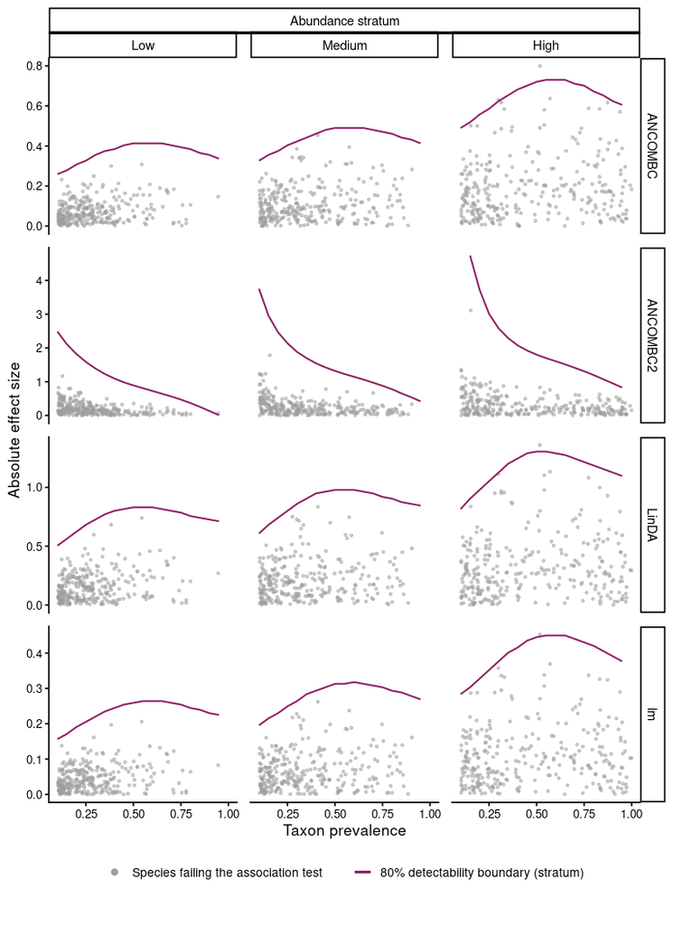

```r
p_bound_BC_model <- plot_effect_size_upper_bounds_abundance(
  res_bound = res_bound_abund_BC,
  methods = methods_keep
)
p_bound_BC_model
```

```r
ggsave(
  filename = file.path(out.loc, paste0("BC_", param_set, "_eff_size_boundaries_real.pdf")),
  plot = p_bound_BC_model,
  device = cairo_pdf,
  width = 8,
  height = 9
)
```

Now let’s visualize this together with the corresponding p-values, to put the ones crossing the boundary in context.

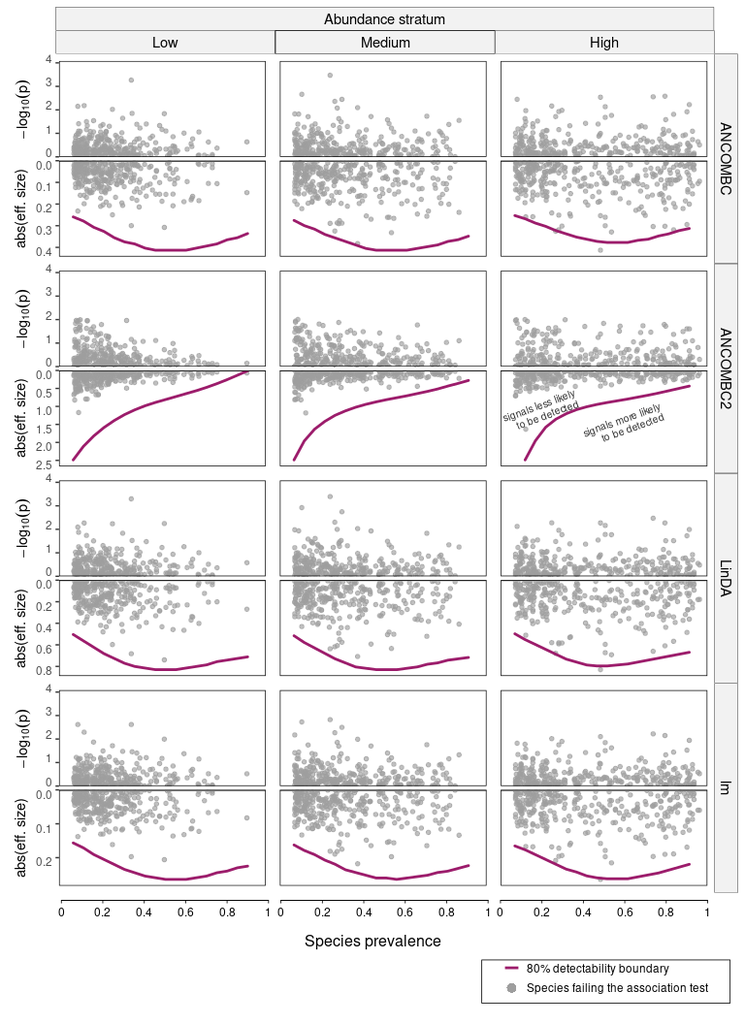

```r
miami_width = 8
miami_height = 11
p_pseudomiami_BC <- plot_pseudomiami_detectability_abundance(
  res_bound = res_bound_abund_BC,
  methods = methods_keep,
  pval_ymax = 4,
  top_fraction = 0.5,
  gap_fraction = 0.05,
  figure_width = miami_width,
  figure_height = miami_height,
  failed_label = "Species failing the association test",
  positive_label = "Positive taxon",
  boundary_label = "80% detectability boundary",
  annotation_method = "ANCOMBC2",
  annotation_stratum = "High",
  annotation_x_lower = 0.8,
  annotation_x_upper = 0.4,
  annotation_angle = 20
)
p_pseudomiami_BC
```

```r
ggsave(
  filename = file.path(out.loc, paste0("BC_", param_set, "_pseudo_miami.pdf")),
  plot = p_pseudomiami_BC,
  device = cairo_pdf,
  width = miami_width,
  height = miami_height
)
```

# 16 Session information

Session information is printed below to document package versions and the computational environment used for the analysis.

[session information not shown]